# Methuselah flies progress report

team rejuve biotech

2023-02-03

# **introduction**

This notebook summarizes analysis of whole genome sequencing and RNAseq data provided by Genescient Corp. on 5 replicates each of three experimentally evolved fruit fly populations:

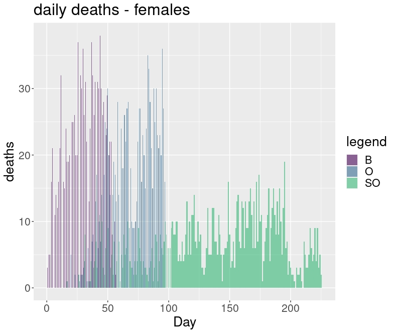

All three populations live 30-40 days after egg harvesting. The potential for within population stratification warrents further study.

- population B with generation period 2 weeks and average lifespan 40 days
- population O with generation period 10 weeks and average lifespan 80 days
- population SO (super O) with generation period 16 weeks and average lifespan 140 days

Run the notebook from the [flies repo](https://gitlab.com/opencog-bio/scV1kg2) `reports` directory to reproduce this R notebook output.

The Methuselah fly project is based on the experimantal evolution of Dresophila melanogaster populations originally developed by Dr Michael Rose in the 1980s. The current populations were developed by Genescient corporation. Samples for seqencing were acquired in August, 2020, as follows:

A pooled sample of 125 female flies was collected from each of the 15 replicate populations for both DNA and mRNA extraction. The sequencing was done by [NovoGene](https://en.novogene.com/), using the Illumina NovaSeq 6000 on 150 base paired end oligonucleotide fragaments prepaired from each pooled sample.

# **Genescient Report Executive Summary**

Genescient produced a summary analysis of the sequencing data with the following summary:

*The services of Dr. Michael R. Rose and Dr. Thomas T. Barter … were retained in order to characterize data obtained by Abbenford Associates and Genescient Inc, under the direction of Dr. Hardip B. Passananti, JD. We examined the longevity data obtained by Genescient, and found it broadly credible. Those data clearly establish that the B, O, and super-O populations are highly differentiated from each other with respect to mean longevity.* *We took raw genome-wide sequencing data obtained by Abbenford Associates, and subjected them to detailed analysis. We find that the 10 O and super-O populations are free of any sign of genetic drift or inbreeding. The five B populations show some evidence of genetic drift reducing heterozygosity and increasing between-replicate differentiation. We also found considerable evidence of a strong signal of genetic differentiation between the three groups of populations.*  
*We took raw transcriptome-wide sequencing data obtained by Abbenford Associates, and subjected them to detailed analysis. We find excellent signatures of transcriptome differentiation among the three groups of populations. Overall, the consultants conclude that the B, O, and super-O populations, as a group, merit continued use as a landmark tool for research on the mechanistic foundations of metazoan aging.*

# **F statistics**

$$F_{st} = \frac{Q_1 - Q_2}{1 - Q_2}$$
where Q<sub>1</sub> is the probabilty, for a given haplotype, of selecting a pair of identical alleles from within compared populations, and Q<sub>2</sub> is the probability of selecting a pair of identical alleles between them.

The F<sub>st</sub> statistic measures the the extent to which a genetic haplotype distinguishes populations, ranging from 0 when the haplotype is uniform across both groups, to 1 when the haplotype uniquely determines the subgroup within the whole population. This notion can be extended to whole genomes by different methods of averaging over sets of haplotypes. The Genescient review reported F<sub>st</sub> values for each population using opensource population genetics software package [popoolation2](https://sourceforge.net/p/popoolation2/wiki/Manual/), after aligning the sequencing reads to reference genome dmel6.14 with bwa-mem. Rejuve calculated similar values using the R package [poolfstat](https://cran.r-project.org/web/packages/poolfstat/index.html), using variants called with GATK4 from the same sequencing reads contained in 1 or 2 pairs of fasta formated files averaging 7.2 Gb pe sample, aligned by bwa-mem to dmel6.22, which differs in the structure of sequences not difinitively mapped to a chromosome.

Gautier M, Vitalis R, Flori L and Estoup A (2022). f-statistics estimation and admixture graph construction with Pool-Seq or allele count data using the R package poolfstat. Molecular Ecology Resources, 22(4):1394-1416

|  | B | O | SO |
| --- | --- | --- | --- |
| popoolpation2 $F_{st}$ | 0.235 | 0.028 | 0.053 |
| poolfstat $F_{st}$ | 0.303 | 0.023 | 0.058 |

The poolfstat method of calculating F<sub>st</sub> is more conservative than popoolation2 because it explicitly accounts for sampling from among the individuals contributing to the pool of haplotype sequences that occurs in the sequencing machine. Differences between base call quality metrics used by popoolation2 and GATK4 may also contribute to the observed differences in F<sub>st</sub> values.

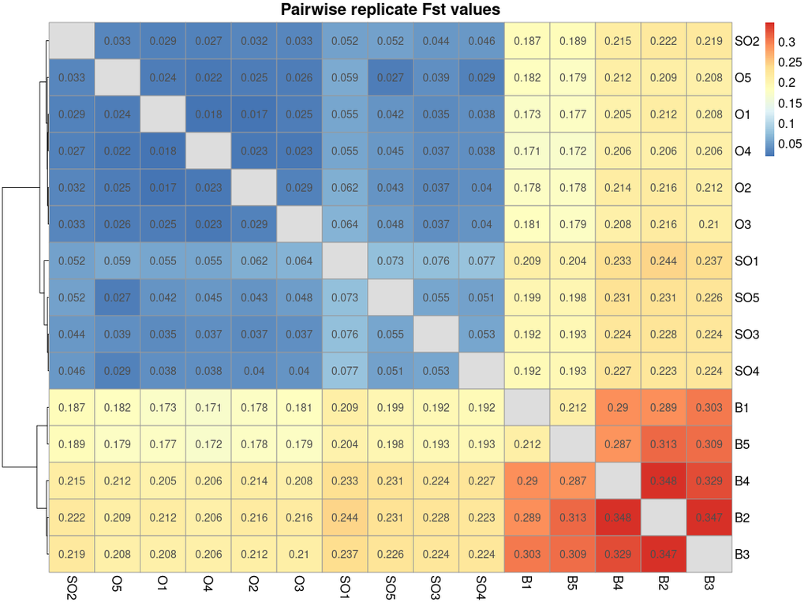

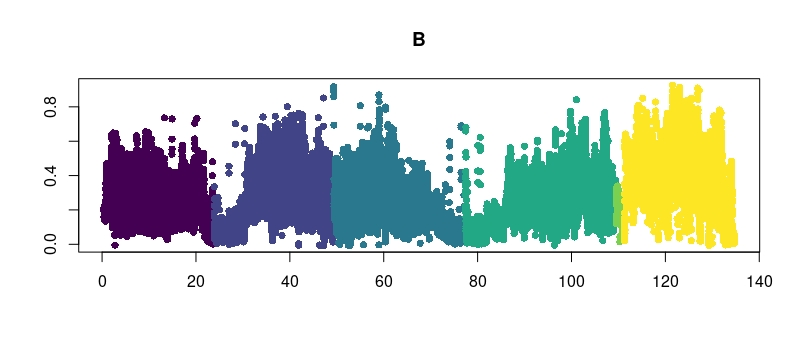

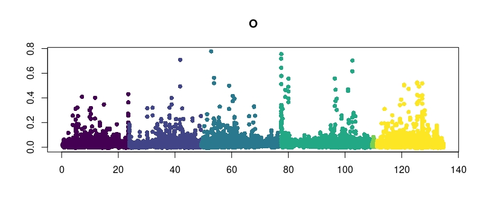

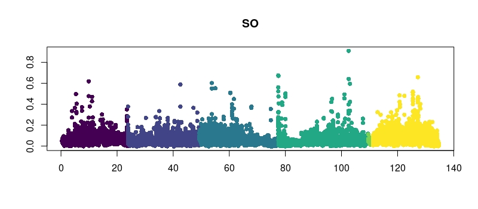

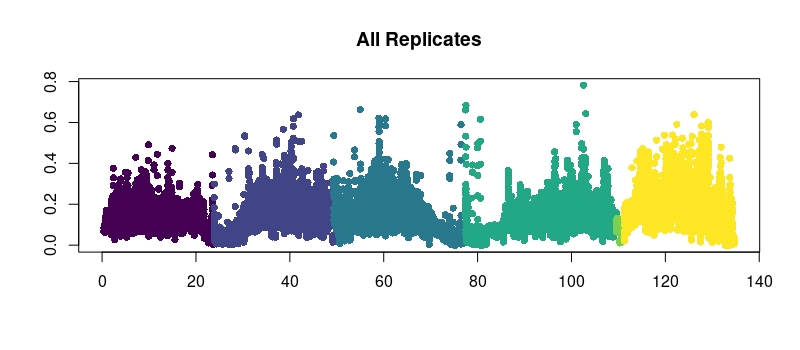

$F_{st}$ in 50 SNP sliding window for chromosomes 2L, 2R, 3L, 3R, 4 and X scaled in cumulative megabases

Calculating the F<sub>st</sub> in a sliding window along the genome highlights regions potentially undergoing selective evolutionary pressure. Comparing manhattan plots for F<sub>st</sub> among all replicates and among the three populations highlights areas of differtial selection for more detailed scrutiny. The plot for the B population highlights the high level of drift among the B replicates.

# **pooled whole genome sequencing**

The pre-processed fastq files provided by Gensescient were sent through the [bcbio_nextgen](https://bcbio-nextgen.readthedocs.io/en/latest/contents/intro.html) pipeline: alignment to reference genome BDGP6 via bwa and GATKv4 variant calling of the resulting BAM files with parameters **–ploidy 250** and **–max-genotype-count 31626** to calibrate quality control for the pooled samples. The Genescient analysis applied an ad hoc filter of greater than 20 reads for SNP inclusion which accounts for the discrepancy in singlton variants. The strong relationship between mitochondrial function and longevity warrants detailed investigation of differential mutation and expression of energetic and metabolic pathways.

| variant set | total | snvs | indels | singletons |
| --- | --- | --- | --- | --- |
| all variants | 2,086,599 | 1,678,670 | 419,956 | 129,797 |
| all chromosome mapped variants | 2,040,154 | 1,639,571 | 412,316 | 121,828 |
| mitochondrial genome variants | 88 | 82 | 6 | 5 |
| all mapped SNPs | 1,663,733 | 1,634,410 | 0 | 81,600 |
| Genescient report SNPs | 1,428,587 | 1,428,587 | 0 | 4,457 |

The open source program snpEff (v5.0e, BDGP6.86) was used to annotate variants with their potential effects on gene expression. Mutations in exons and splicing areas can directly affect amino acid sequences of protein products, but effects on gene expression levels can be affected by mutations in introns and intergenic/upstream/downstream regions (potential enhancer sites) and affected genes aren’t necessarily the ones closest to the variant site, greatly complicating the search for causal mutations.

© 2018 by Steven M. Carr

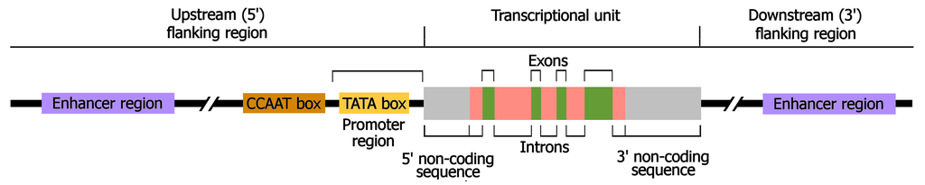

snpEff variant counts by Sequence Ontology gene region

| location | count |
| --- | --- |
| downstream | 2,790,465 |
| exon | 611,960 |
| gene | 328 |
| intergenic | 687,029 |
| intron | 4,339,575 |
| splice site acceptor | 555 |
| splice site donor | 494 |
| splice site region | 42,887 |
| transcript | 579 |
| upstream | 2,869,073 |
| utr 3 prime | 215,829 |
| utr 5 prime | 124,471 |

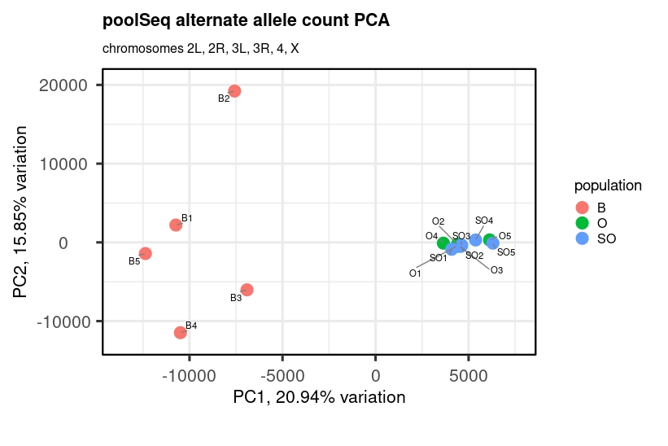

PCA of normalized SNP alt counts again shows the genetic drift among the Bs compared to the O and SO population replicates.

A principle component analysis of alternate allele frequency estimates shows the drift in the B populations, with B replicates farther from each other compared to the Os and SOs clustered tightly together.

Given the low sequencing coverage of the samples (average ~ 8x per replicate) with 125 flies per pooled replicate, estimated allele frequencies are in general not significant after multiple testing correction and higher coverage WGS is required for fine structure analysis.

The mean number of single nucleotide variants (SNVs) are

| population | mean snvs |
| --- | --- |
| B | 1,081,347 |
| O | 1,324,643 |
| SO | 1,294,700 |

and we can see the previously observed finding that the long lived phenotype is associated with many more variants than normal, with Os and SOs having 22% and 20% more SNVs, respectively, than Bs. Intriguingly, the slightly smaller variant burden in the SOs (by 2%) suggests that the super-long lived phenotype might be converging on a smaller set of altered pathways than is required for the more modest life extension in the Os. In other words, there may be more ways to be an O fly than an SO fly.

# **pooled RNA expression levels**

Transcriptome anlaysis was done using the [Salmon](https://github.com/COMBINE-lab/salmon) k-mer based quasi-alignment method to quantify expression and [DESeq2](https://bioconductor.org/packages/release/bioc/html/DESeq2.html) to calculate differential expression between populations.

Patro, R., Duggal, G., Love, M. et al. Salmon provides fast and bias-aware quantification of transcript expression. Nat Methods 14, 417–419 (2017)

Love, M.I., Huber, W., Anders, S. Moderated estimation of fold change and dispersion for RNA-seq data with DESeq2 Genome Biology 15(12):550 (2014)

The bar chart in the right margin shows increasing numbers of differentially expressed (DE) genes comparing Bs to Os to SOs.

Functional analysis of differential expression using over representation of DE genes in [Gene Ontology](http://geneontolgy.org) (GO) categories shows

T Wu, E Hu, S Xu, M Chen, P Guo, Z Dai, T Feng, L Zhou, W Tang, L Zhan, X Fu, S Liu, X Bo, and G Yu. clusterProfiler 4.0: A universal enrichment tool for interpreting omics data. The Innovation. 2021, 2(3):100141

- Os have greater representation than Bs in carbohydrate, amino acid, and nucleotide metabolic processes.
- SOs have greater representation than Os in respiration, ATP metabolism, and ion transport processes.
- SOs have greater representation than Bs in aerobic respiration & mitochondrial processes but less representation in processes related to DNA replication and cell devision.

Pooled RNA samples were taken within a week post eclosion in all replicates, which is potentially a different phase of adult life in each population so full interpretation requires longitudinal transcriptome sampling at proportionally equivalent time points.

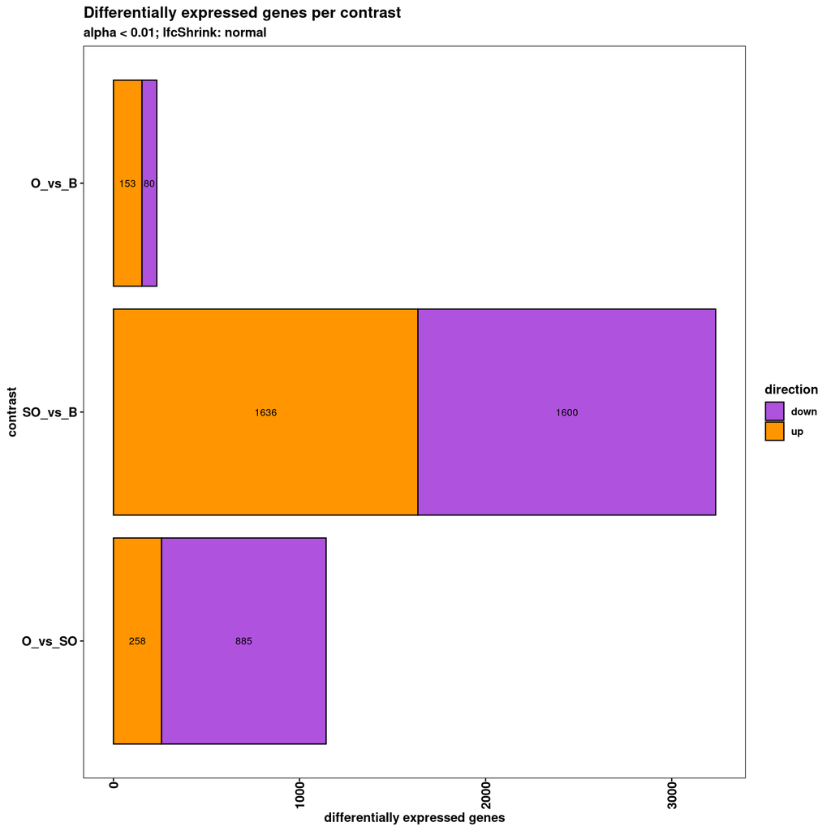

counts by population contrast of differentially expressed transcripts aggregated by gene: from top to bottom O vs B, SO vs B, O vs SO

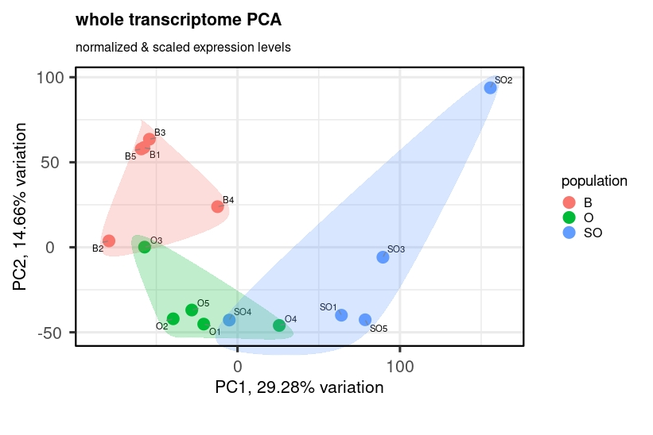

PCA plot of expression levels by replicate shows separation of SOs from the Bs and Os by the first component and separation of Bs and Os by the second component.

# **NetAct**

NetAct is an R pipeline for inferring gene regulatory networks (GRNs) from transcriptome expression data and documented transcription factor target sets. Su, et al define a construct called “activity” to compare transcription factors (TFs) between groups of sample transcriptomes based on expression levels of predefined TF target sets as well as the TF expression levels themselves. This measure is shown to be more robust than methods that only compare TF differential expression.  
Mutual information between the most “active” TFs based on expression patterns and the documented TFs and target sets (background knowledge) are used to define a TF GRN. This GRN is then simulated with an ensemble of dynamical network models with random rate coefficients ([stochastic RAndom CIrcuit PErturbation](https://github.com/vivekkohar/sRACIPE)). Steady states of the random models in the ensemble form clusters representing biochemically plausible expression phenotypes as an in silico validation of the network model, inferred solely from network topology.

Kenong Su, Ataur Katebi, Vivek Kohar, Benjamin Clauss, Danya Gordin, Zhaohui S. Qin, R. Krishna M. Karuturi, Sheng Li, Mingyang Lu. NetAct: a computational platform to construct core transcription factor regulatory networks using gene activity. bioRxiv 2022.05.06.487898; doi: https://doi.org/10.1101/2022.05.06.487898

Kohar, V. and Lu, M., Role of noise and parametric variation in the dynamics of gene regulatory circuits, npj Systems Biology and Applications volume 4, Article number: 40 (2018)

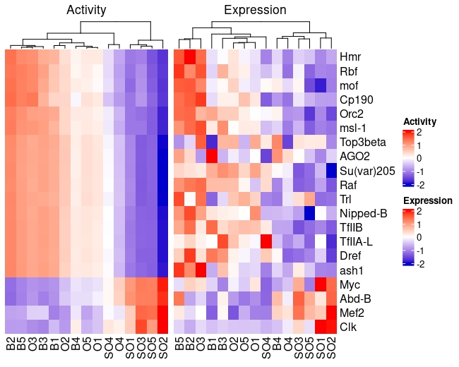

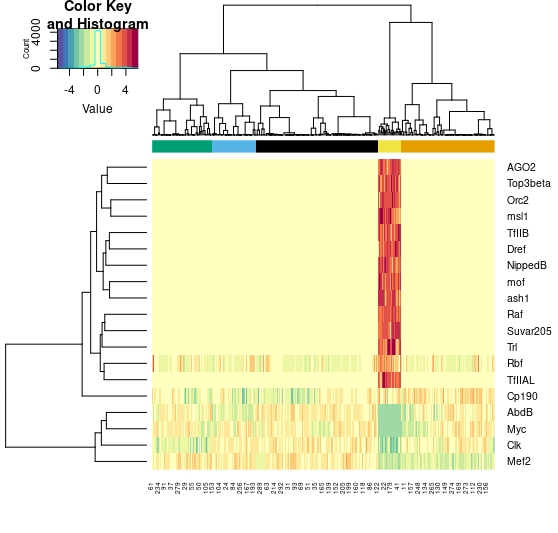

The clustered heatmaps of activity and expression roughly match the grouping of replicates into their respective populations (top). The clustered steady state activation pattern of the inferred TF GRN provides in silico validation of the network as a plausible mechanism reproducing the long lived expression phenotype evolved in the SO replicates (bottom).

Bray, N., Pimentel, H., Melsted, P. et al. Near-optimal probabilistic RNA-seq quantification. Nat Biotechnol 34, 525–527 (2016). https://doi.org/10.1038/nbt.3519

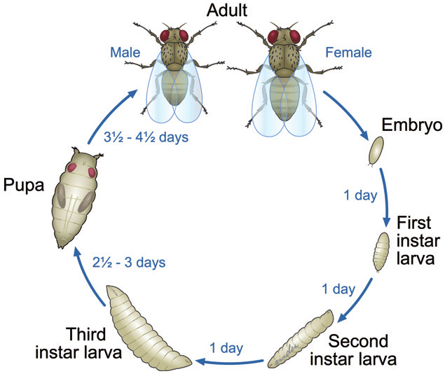

Ong C, Yung LY, Cai Y, Bay BH, Baeg G. (2014). Drosophila melanogaster as a model organism to study nanotoxicity. Nanotoxicology. 9. 1-8. 10.3109/17435390.2014.940405.

Harvesting at two additional points during the life-cycle are planned: at the end of the generation (pre-egg laying) period and midway between egg-laying and average age at death of the respective populations to further elucidate the long lived expression phenotype through the fly life span.

# **Next Steps**

## **mitochondrial analysis**

## **projection to latent structure (PLS)**

## **supervised mix-omics methods**

## **bio-atomspace pattern matching & graph completion**

## **indel and mvn haplotype analysis**

## **regional fine-mapping of significant variants**

## **variant burden testing**

## **structural variant analysis**